# midterm

3

2024-02-21

```r
raw = read.csv('Electric_Vehicle_Sales_Data.csv')
```

## Motivation

One major component of the industrial economy here in the United States and around the world is the automotive industry. An exciting development in that industry, one with potential to have a salutary impact on the environment, is the shift toward electric vehicles. Prior to 2012, electric vehicle sales were almost negligible. In the year 2011, a total of 17,763 “plug-in” vehicles - either fully battery powered or plug-in hybrid - were sold in the United States. In 2023, there were 1.5 million such vehicles sold. Such a shift in the fueling of transportation has significant ramifications for our collective energy needs for future decades. Most immediately, it likely augurs a decline in demand for petroleum and an increase in demand for electricity. It’s easy to see that there are many entities and industries that would have a significant interest in the trend of electric vehicle sales. The purpose of this project is to analyze the trend in the sales of battery powered vehicles in the United States.

## The Data

The data comes from *Argonne National Laboratory* [^1] which they compiled from a number of different sources. The dataset contains, for each month and year, the total number of battery-powered vehicles (*BEV*), plug-in hybrid (*PHEV*), hybrid-electric vehicles (*HEV*), and the total number of light-duty vehicles sold (*LDV*). The dataset appears to be complete and without any apparent missing value or wrong entries. The sales figures are recorded from December of 2010 through January of 2024.

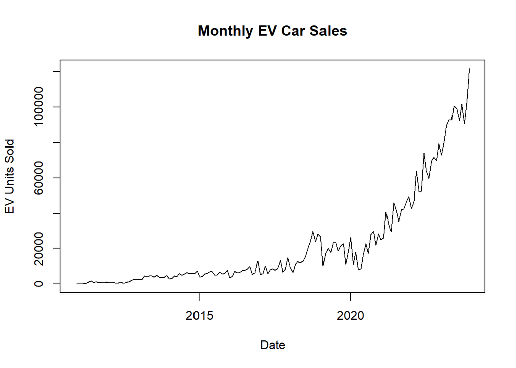

```r
#install.packages(c('zoo', 'knitr'))
library(zoo)

ev_sales <- read.csv('Electric_Vehicle_Sales_Data.csv')
#print(c(length(as.Date(as.yearmon(ev_sales$Month, format='%y-%b'))), length(ev_sales$BEV)))
ev_sales$Date <- as.Date(as.yearmon(ev_sales$Month, format='%b-%y'))
#head(ev_sales)
bev <- ev_sales[1:157,c(2, 6)]
plot(bev$Date,bev$BEV, type='l', main = 'Monthly EV Car Sales', xlab = 'Date', ylab = 'EV Units Sold')
```

## Exploratory Data Analysis

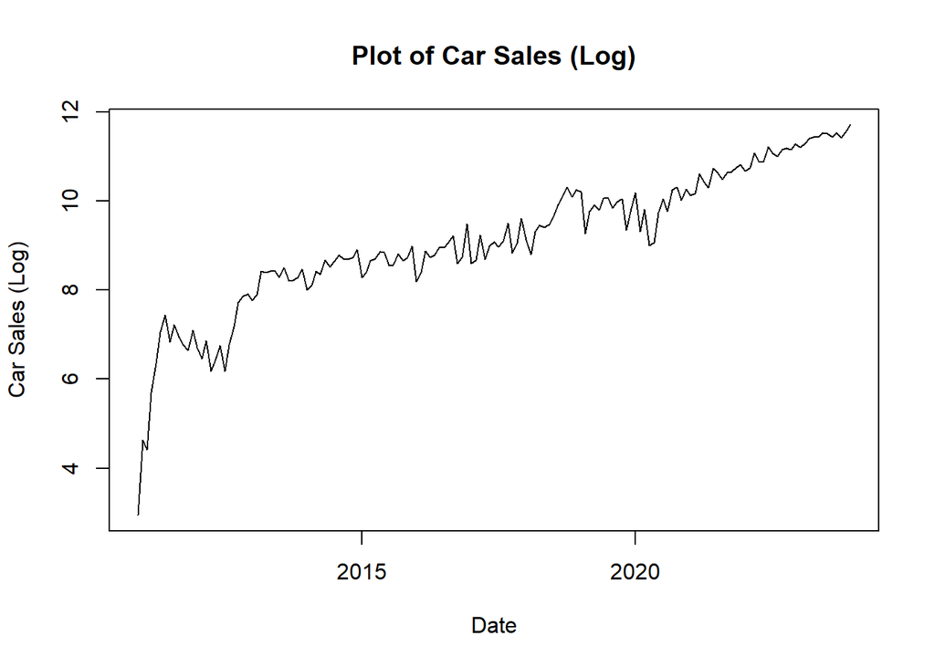

```r
plot(bev$Date, log(bev$BEV), type = 'l', main = 'Plot of Car Sales (Log)', xlab='Date',  ylab='Car Sales (Log)')
```

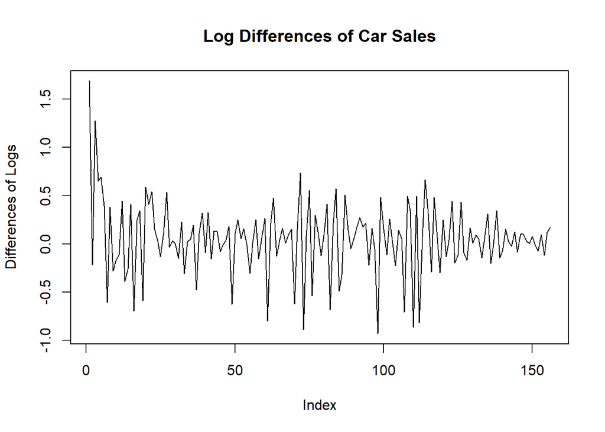

```r
plot(diff(log(bev$BEV)), type='l', main = 'Log Differences of Car Sales', ylab = 'Differences of Logs')
```

# Model Exploration

To explore a large amount of different ARMA models, we generated a table that would create ARMA models with varying values of p and q. We used AIC values first from the various models to help identify good candidates to further analyze. These ARMA(p,q) models will be fit according to equation [M9] on slide 13 in lecture 4:

$$Y_n = \mu + \phi_1Y_{n-1} +
\phi_2Y_{n-2} + \cdot\cdot\cdot +\phi_pY_{n-p}+\epsilon_n
+\psi_1\epsilon_{n-1} + \psi_2\epsilon_{n-2} + \cdot\cdot\cdot +
\psi_q\epsilon_{n-q}$$

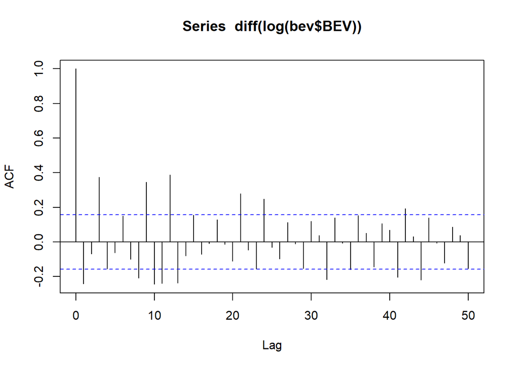

```r
acf(diff(log(bev$BEV)), lag.max=50)
```

```r
library(knitr)
aic_table <- function(data,P,Q){
  table <- matrix(NA,(P+1),(Q+1))
  for(p in 0:P) {
    for(q in 0:Q) {
    try(table[p+1,q+1] <- arima(data,order=c(p,1,q), method='ML')$aic)
    }
  }
  dimnames(table) <- list(paste("AR",0:P, sep=""),
    paste("MA",0:Q,sep=""))
  table
}
aic_table2 <- aic_table(log(bev$BEV),12,12)

kable(aic_table2,digits=2)
```

[output not shown]

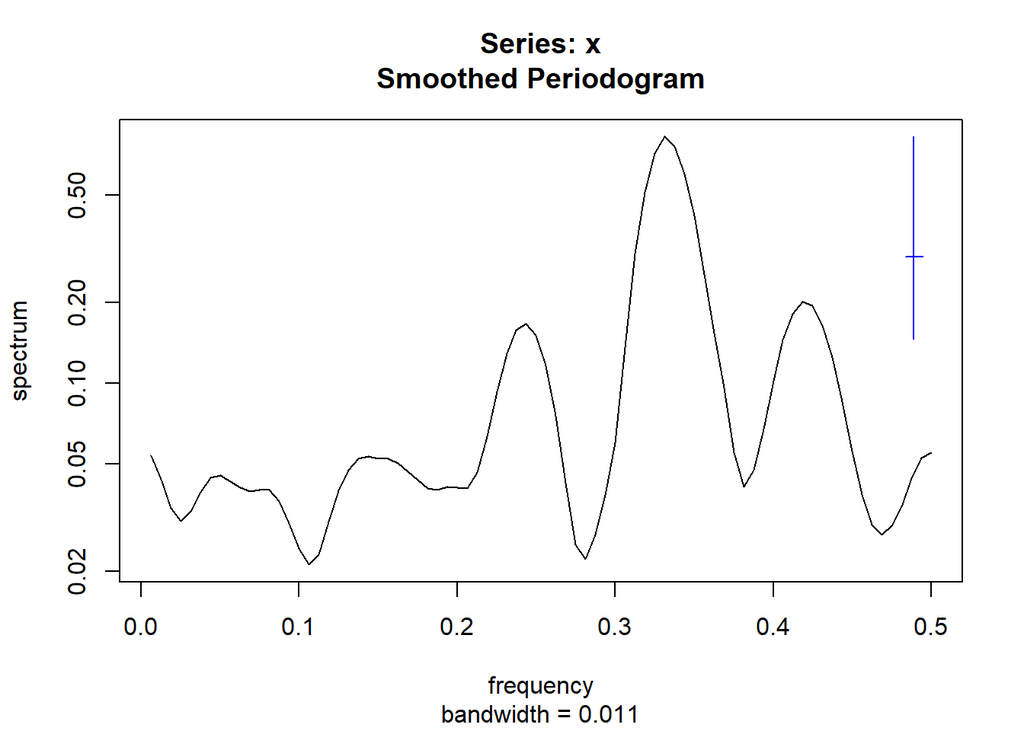

```r
spectrum(diff(log(bev$BEV)), spans=c(4,4))
```

```r
s = spectrum(diff(log(bev$BEV)), method = 'ar')
```

[figure not shown]

```r
print(s$freq[which.max(s$spec)])
```

```
## [1] 0.3336673
```

## Model Results and Analysis

```r
model_1 <- arima(log(bev$BEV), order=c(10,1,6), method='ML')
model_1
```

```
##
## Call:
## arima(x = log(bev$BEV), order = c(10, 1, 6), method = "ML")
##
## Coefficients:
##          ar1     ar2     ar3     ar4     ar5      ar6      ar7      ar8     ar9
##       0.0249  0.0677  0.9910  0.0366  0.0325  -0.9048  -0.0781  -0.2012  0.4884
## s.e.  0.0966  0.0810  0.0822  0.1148  0.0902   0.0890   0.1180   0.0812  0.0845
##          ar10      ma1     ma2      ma3     ma4     ma5     ma6
##       -0.1600  -0.0716  0.0502  -0.7501  0.0155  0.0323  0.9347
## s.e.   0.1001   0.0605  0.0586   0.0531  0.0586  0.0589  0.0691
##
## sigma^2 estimated as 0.06883:  log likelihood = -20.51,  aic = 75.02
```

```r
model_95 = arima(log(bev$BEV), order= c(9,1,5), method='ML')
```

```r
test_stat <- model_1$loglik - model_95$loglik
print(1-pchisq(2*test_stat, 2))
```

```
## [1] 0.08057017
```

```r
AR_roots <- polyroot(c(1,-coef(model_95)[c("ar1", 'ar2', "ar3", 'ar4', "ar5", 'ar6' ,"ar7", 'ar8' ,"ar9")]))
MA_roots <- polyroot(c(1,coef(model_95)[c("ma1", 'ma2', 'ma3' ,'ma4', 'ma5')]))
print(Mod(AR_roots))
```

```
## [1] 1.051802 1.061520 1.002421 1.061520 1.029054 1.051802 1.438378 1.029054
## [9] 4.853752
```

```r
print(Mod(MA_roots))
```

```
## [1] 1.000010 1.031265 1.000010 1.010839 1.031265
```

```r
aic_table2 <- function(data,P,Q){
  table <- matrix(NA,(P+1),(Q+1))
  for(p in 0:P) {
    for(q in 0:Q) {
    try(table[p+1,q+1] <- arima(data,order=c(p,2,q), method='ML')$aic)
    }
  }
  dimnames(table) <- list(paste("AR",0:P, sep=""),
    paste("MA",0:Q,sep=""))
  table
}
aic_table22 <- aic_table2(log(bev$BEV),12,12)

kable(aic_table22,digits=2)
```

[output not shown]

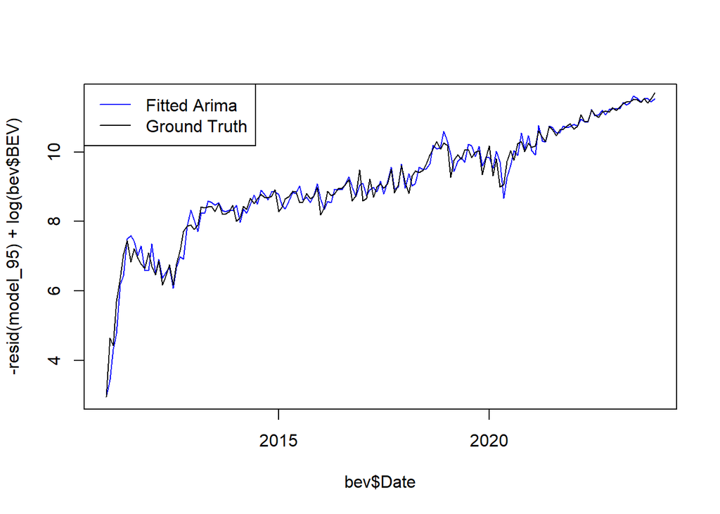

```r
plot(bev$Date, -resid(model_95) + log(bev$BEV), type='l', col='blue')
lines(bev$Date, log(bev$BEV), col='black')
legend('topleft', legend=c('Fitted Arima', 'Ground Truth'), col=c('blue','black'),lty=1)
```

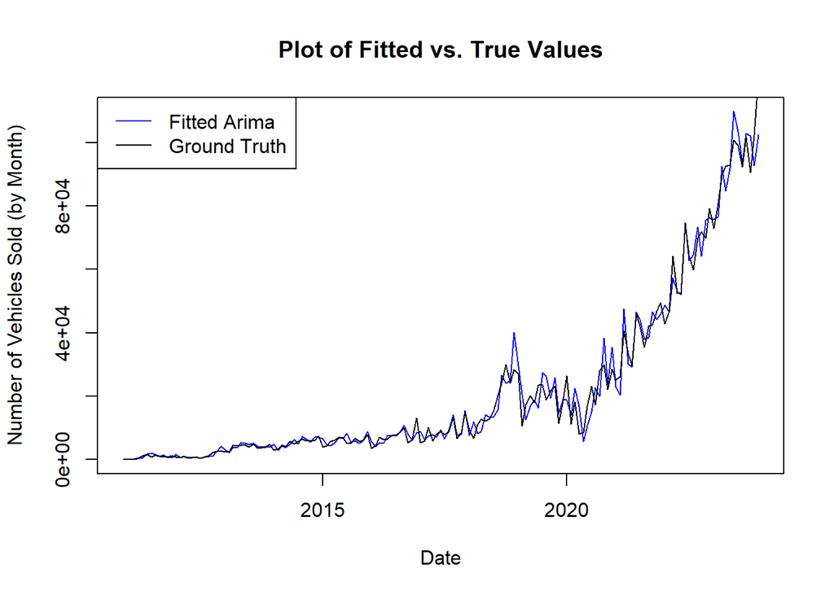

```r
plot(bev$Date, exp(-resid(model_95) + log(bev$BEV)), type='l', col='blue', main='Plot of Fitted vs. True Values',
     xlab='Date', ylab='Number of Vehicles Sold (by Month)')
lines(bev$Date, exp(log(bev$BEV)), col='black')
legend('topleft', legend=c('Fitted Arima', 'Ground Truth'), col=c('blue','black'),lty=1)
```

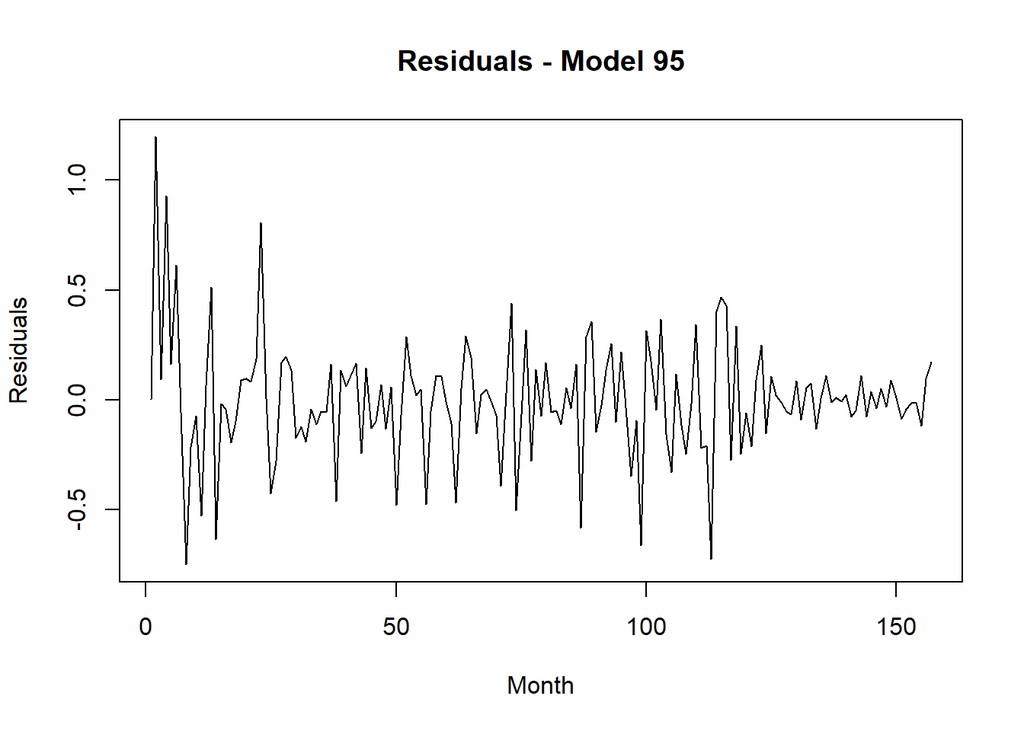

```r
plot(model_95$residuals,main='Residuals - Model 95',ylab='Residuals',xlab='Month')
```

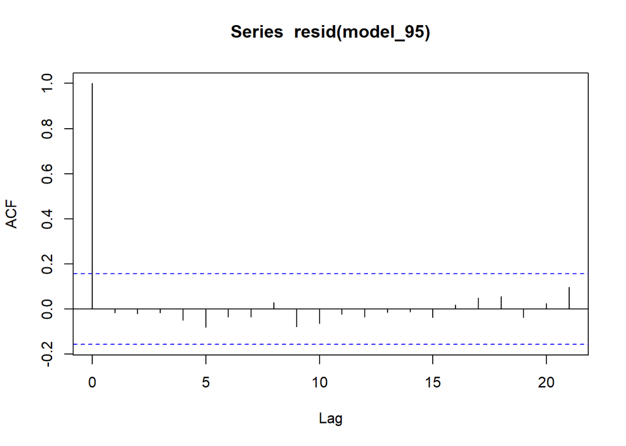

```r
acf(resid(model_95))
```

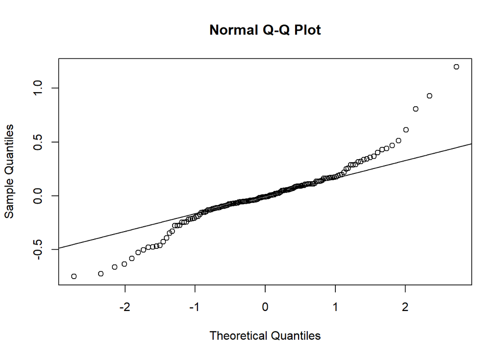

```r
qqnorm(model_95$residuals)
qqline(model_95$residuals)
```

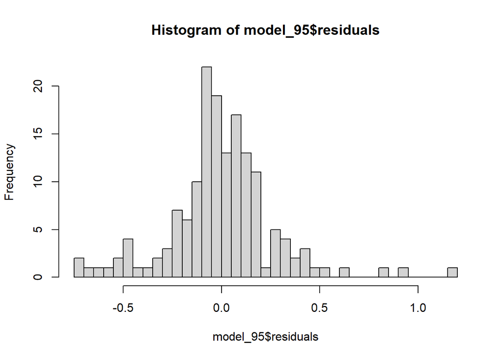

```r
hist(model_95$residuals, breaks=30)
```

```r
model_2 <- arima(log(bev$BEV), order=c(9,1,5), seasonal=list(order=c(0,0,2), period=3), method='ML')
model_2
```

```
##
## Call:
## arima(x = log(bev$BEV), order = c(9, 1, 5), seasonal = list(order = c(0, 0,
##     2), period = 3), method = "ML")
##
## Coefficients:
##           ar1      ar2     ar3     ar4     ar5      ar6      ar7      ar8
##       -0.6736  -0.2486  0.7338  0.6869  0.5314  -0.5131  -0.6079  -0.6621
## s.e.   0.0046   0.0079     NaN  0.0080     NaN   0.0013   0.0082   0.0041
##          ar9     ma1     ma2     ma3     ma4      ma5     sma1    sma2
##       -2e-04  0.6345  0.3323  0.4349  0.0423  -0.1534  -0.8046  0.8876
## s.e.     NaN     NaN  0.0100  0.0110  0.0033   0.0020   0.0075  0.0168
##
## sigma^2 estimated as 0.07081:  log likelihood = -20.48,  aic = 74.96
```

```r
library(forecast)
model_best <- auto.arima(log(bev$BEV), max.p=15, max.q=15, d=1, D=3, seasonal=TRUE)
summary(model_best)
```

```
## Series: log(bev$BEV)
## ARIMA(3,1,2) with drift
##
## Coefficients:
##           ar1      ar2     ar3      ma1     ma2   drift
##       -0.1959  -0.0664  0.3982  -0.0176  0.0452  0.0607
## s.e.   0.2390   0.2364  0.1189   0.2433  0.2104  0.0316
##
## sigma^2 = 0.1115:  log likelihood = -47.52
## AIC=109.05   AICc=109.8   BIC=130.4
##
## Training set error measures:
##                        ME      RMSE       MAE        MPE     MAPE      MASE
## Training set -0.004715886 0.3264336 0.2212311 0.05336021 2.716116 0.8252022
##                     ACF1
## Training set -0.01711247
```

```r
test_stat <- model_95$loglik - model_best$loglik
print(1-pchisq(2*test_stat, 9))
```

```
## [1] 1.663863e-07
```

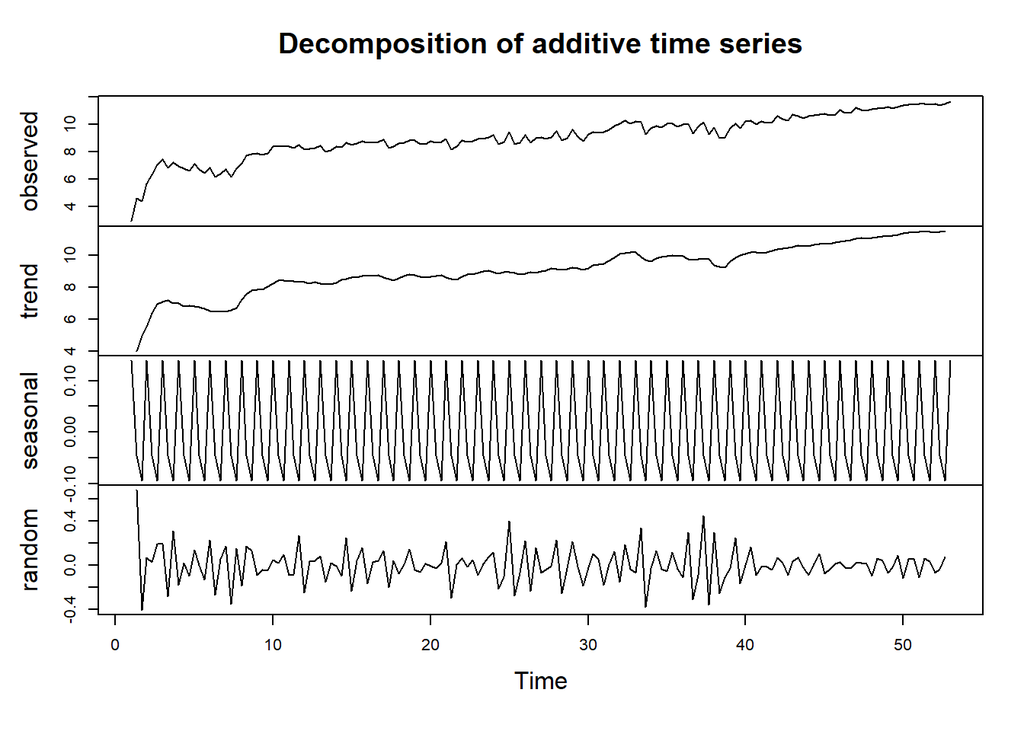

```r
dc <- decompose(ts(log(bev$BEV), frequency=3))
plot(dc)
```

## Comparison with all LDV Sales

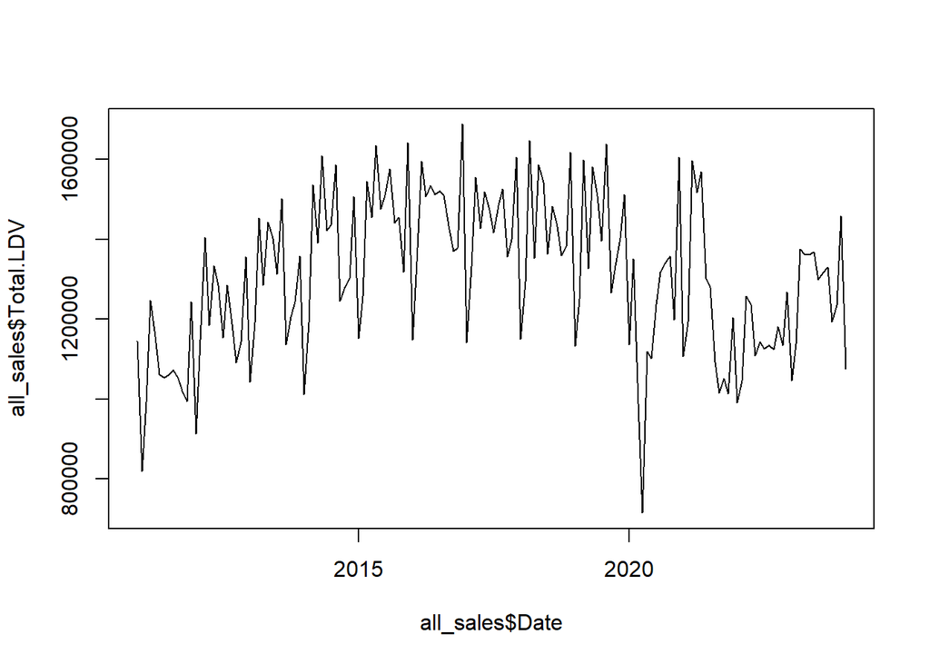

```r
all_sales = ev_sales[,2:6]
all_sales['ratio'] =  all_sales$BEV / all_sales$Total.LDV
plot(all_sales$Date, all_sales$Total.LDV, type='l')
```

## Prediction

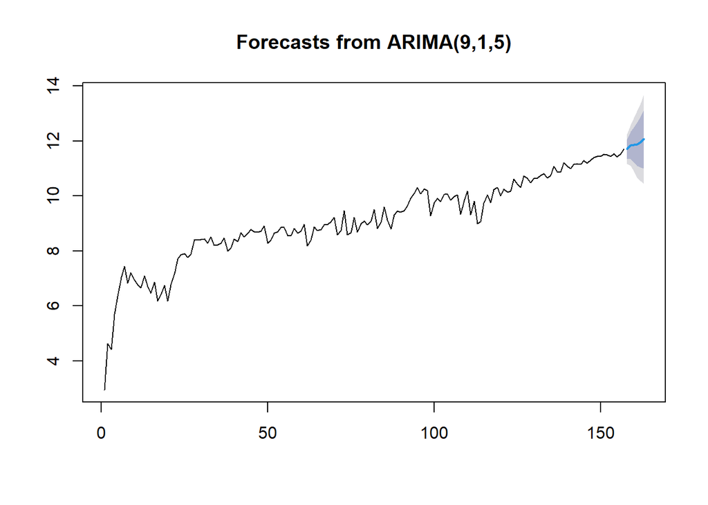

```r
prediction_log = forecast(model_95, h=6)
plot(prediction_log)
```

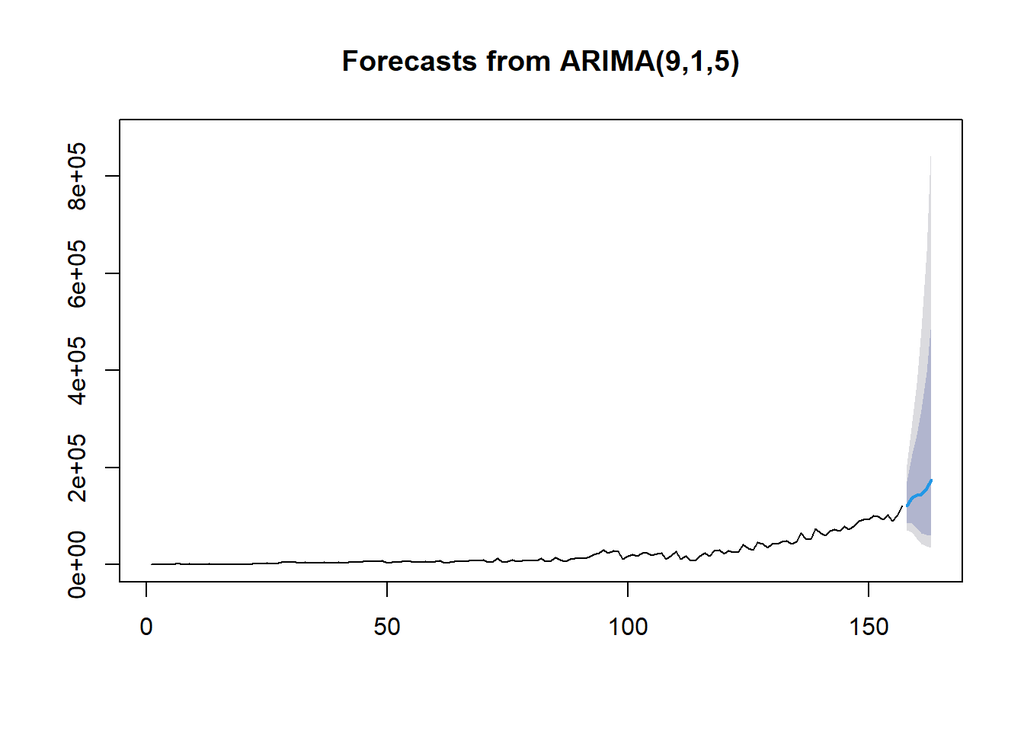

```r
ff <- forecast(model_95, h = 6)
ff$x <- exp(ff$x)
ff$mean <- exp(ff$mean)
ff$lower <- exp(ff$lower)
ff$upper <- exp(ff$upper)
plot(ff)
```

[^1]: https://www.anl.gov/esia/light-duty-electric-drive-vehicles-monthly-sales-updates